# YanniSun_Midterm_Project_Spring2023

## Understanding Naive Byes Classifier

Name: Yanni Sun

In machine learning, a **classifier** is an algorithm that automatically assigns data points to one or more of a set of “classes”. There are two main models: supervised and unsupervised.

Supervised classifiers: training datasets have labeled data (output column) and feature variables(input columns). We can build model by fitting with training datasets. Then we can use the model to predict which class a new input data may belong to.

Unsupervised classifiers: there is no labeled column in datasets. The classification based on pattern recognition or structures and anomalies in the data. At begining, we even do not know how many classes there and what the classes are. We may need to tune the model by hyper parameter of how many classes there are.

**Naive Bayes classifiers** is one of common types of classification algorithms. It predicts the probability that a data point fits into each classification, and then outputs the class that has the highest probability.

Naive Bayes classifiers are based on the Bayes Theorem: $$ P(C~|~{\rm features}) = \frac{P({\rm features}~|~C)P(C)}{P({\rm features})} $$ 𝑃(𝐶 | features) is the posterior probability of a label/class (target) given some observed features (predictor). It is what we would like to predict for testing data. 𝑃(features | 𝐶) is the likelihood which is the probability of predictor given class.𝑃(𝐶) is the prior probability of class. 𝑃(features) is the prior probability of features.

All naive Bayes classifiers assume that the value of a particular feature is independent of the value of any other feature, given the class variable. Even though some of the features may have possible correlations between them in practice, we will ignore those correlations. All the calculations must based on the assumption that all features are independent to all other features.

For example, if there are m features (columns): $x_1$, ... $x_i$, ... $x_m$, and they are independent, with Bayes theorem, the probability that the observed data point belongs to class 𝐶𝑘 can be calculated as

$$P(C_k | x_1, \dots x_i, \dots x_m) = \frac{P(x_1, \dots x_i, \dots x_m | C_k)\cdot P(C_k)}{P(x_1, x_2, \dots x_i, \dots x_m)} = \frac{P(x_1 | C_k) \dots P(x_i | C_k) \dots P(x_m |C_k)\cdot P(C_k)}{P(x_1, x_2, \dots x_i, \dots x_m)} = \frac{\prod_{i=1}^{m}P(x_i | C_k)\cdot P(C_k)}{P(x_1, x_2, \dots x_i, \dots x_m)}$$

The denominator ${P(x_1, x_2, \dots x_i, \dots x_m)}$ doesn't depend on $C_k$. It is a constant for any class. We can denote it as $Z$. Then the probability that the observed data point belongs to class 𝐶𝑘 can be written as

$$P(C_k | x_1, \dots x_i, \dots x_m) = \frac{\prod_{i=1}^{m}P(x_i | C_k)\cdot P(C_k)}{Z}.$$

Since Naive Bayes classifiers is to finally predict the class that has the highest probability (Assume there are total K classes), we can ignore the constant $Z$.

$$\hat{k} = \underset{k=1,..,K}{\operatorname{argmax}} \, P(C_k)\cdot \prod_{i=1}^{m}P(x_i | C_k).$$

Here, $P(C_k)$ can be calculated with training dataset (each row is one observation):

$$P(C_k) = \frac{Total \ row \ number \ belong \ to \ class \ 𝐶𝑘}{Total \ row \ number}.$$

When calculate $P(x_i | C_k)$, we should first have assumption of distribution of feature $x_i$, learning the parameters of the probability function based on training dataset. Then for the observation/row j in testing dataset, we can input the value of column/feature $x_i$ for point j into the to probability function (parameters learned from trainign dataset) to calculate $P(x_i | C_k)$.

To explain Naive Bayes classifiers intuitively, I use a simple sample to calculate manually step by step:

**Step 1: Gaussian distribution asssumption**

For convenient calculation, I just created 10 observations in training dataset. There are one feature 'Height' and 2 classes (male and female). Assume 'Height' is Gaussian Distribution (for each class, it is normal distribution). The probability density function for the normal distribution is

$$𝑃(Height|C_k) = {\mathcal{f}(Height) = \sqrt{\frac{1}{2 \pi\sigma_k^2}} exp \Biggr(- \frac{1}{2\sigma_k^2} (Height - \mu_k)^2 \Biggr)}$$

Below is a sample figture for one dimention (feature) Gaussian Distribution with 2 classes:

```python
%matplotlib inline
import matplotlib
matplotlib.rcParams['figure.figsize'] = [10, 6.18]

import numpy as np
import matplotlib.pyplot as plt

# seed the random number generator so we all get the same results
np.random.seed(17)

# some nice colors from http://colorbrewer2.org/
COLOR1 = '#7fc97f'
COLOR2 = '#beaed4'
```

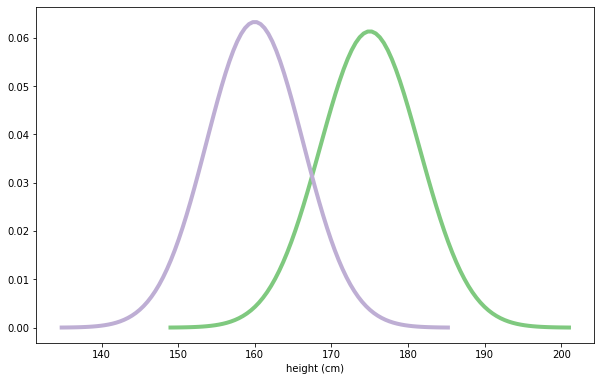

```python
import scipy
num = 4
mu1, sig1 = 175, 6.5  # 175 is mean, 6.5 is standard deviation
male_height = scipy.stats.norm(mu1, sig1)
mean1, std1 = male_height.mean(), male_height.std()
xs1 = np.linspace(mean1 - num*std1, mean1 + num*std1, 100)
ys1 = male_height.pdf(xs1)
plt.plot(xs1, ys1, label='male', linewidth=4, color=COLOR1)

mu2, sig2 = 160, 6.3
female_height = scipy.stats.norm(mu2, sig2)
mean2, std2 = female_height.mean(), female_height.std()
xs2 = np.linspace(mean2 - num*std2, mean2 + num*std2, 100)
ys2 = female_height.pdf(xs2)
plt.plot(xs2, ys2, label='female', linewidth=4, color=COLOR2)
plt.xlabel('height (cm)')
```

**Step 2: Parameter learning**

There are two parameters (mean and standard deviation) in the probability density function. We can learn these parameters with the data from training dataset.

```python
# create training dataset
import pandas as pd
d = {'Height': [156, 178,182,161,179,162,165,182,175,173],
     'Gender': ['female', 'male', 'male','female','male','female','female','male','male','male']}
df = pd.DataFrame(data=d)
print(df)
```

```
   Height  Gender
0     156  female
1     178    male
2     182    male
3     161  female
4     179    male
5     162  female
6     165  female
7     182    male
8     175    male
9     173    male
```

```python
mean_male = df[df.Gender=='male'].Height.mean()
std_male = df[df.Gender=='male'].Height.std()
print('mean for class male is {:.2f}, standard deviation for class male is {:.2f}'.format(mean_male,std_male))
```

```
mean for class male is 178.17, standard deviation for class male is 3.66
```

```python
mean_female = df[df.Gender=='female'].Height.mean()
std_female = df[df.Gender=='female'].Height.std()
print('mean for class female is {:.2f}, standard deviation for class female is {:.2f}'.format(mean_female,std_female))
```

```
mean for class female is 161.00, standard deviation for class female is 3.74
```

For class male, probability density function is $$𝑃(Height|male) = {\mathcal{f}(Height) = \sqrt{\frac{1}{2 \pi*(3.66)^2}} exp \Biggr(- \frac{1}{2*(3.66)^2} (Height - 178.17)^2 \Biggr)}$$

For class female, probability density function is $$𝑃(Height|female) = {\mathcal{f}(Height) = \sqrt{\frac{1}{2 \pi*(3.74)^2}} exp \Biggr(- \frac{1}{2*(3.74)^2} (Height - 161)^2 \Biggr)}$$

**Step 3: plugging observations in testing dataset into the probability density function**

We can have many observations in testing dataset. Here we only use one observation (Height=159) as example to calculate the probability of each class (male/female) given the observations.

```python
# create testing dataset
d_test = {'Height': [159,181]}
df_test = pd.DataFrame(data=d_test)
print(df_test)
```

```
   Height
0     159
1     181
```

```python
import numpy as np
import math
def pdf_class(Height,mu,sigma):
  pi = math.pi
  a=np.sqrt(1/(2*pi*(sigma**2)))
  b=(-1)*(Height-mu)**2
  c=np.exp(b/(2*(sigma**2)))
  return a*c
```

```python
p_height_male = pdf_class(159,mean_male,std_male)
print('The probability for male to have height 159 is {}'.format(p_height_male))
```

```
The probability for male to have height 159 is 1.1747879308042132e-07
```

```python
p_height_female = pdf_class(159,mean_female,std_female)
print('The probability for female to have height 159 is {:.2f}'.format(p_height_female))
```

```
The probability for female to have height 159 is 0.09
```

From above calculation, we can get $$P(Height=159|male) = 1.1747879308042132e-07$$ $$P(Height=159|female) = 0.09$$

**Step 4: calculating prior probability of class (male/female)**

There are total 10 observations in training dataset, including 6 male and 4 female. So the prior probability for each class is: $$P(male) = 6/10 = 0.6$$ $$P(female) = 4/10 = 0.4$$

```python
p_male = df[df.Gender=='male'].shape[0]/df.shape[0]
p_female = df[df.Gender=='female'].shape[0]/df.shape[0]
p_male, p_female
```

```
(0.6, 0.4)
```

**Step5: calculating posterior probability and predict**

As we expained before, we will ignore the denominator 𝑃(𝑥1,𝑥2,…𝑥𝑖,…𝑥𝑚) in the posterior probability since it is not associate with classes, which is our target that need predict. I will denote this partial posterior probability as $P_p$.

The partial posterior probability that Height=159 in testing dataset belongs to male is $$P_p(male|Height=159) = P(male)\cdot P(Height = 159 | male) = 0.6*1.175𝑒−07 = 7.049e-08$$ The partial probability that Height=159 in testing dataset belongs to female is $$P_p(female|Height=159) = P(female)\cdot P(Height = 159 | female) = 0.4*0.09 = 0.036$$ Since $P_p(female|Height=159)$ is higher than $P_p(male|Height=159)$, the predict class for the observation height=159 is female.

```python
p_male_height = p_male * p_height_male
p_female_height = p_female * p_height_female
p_male_height, p_female_height
```

```
(7.048727584825279e-08, 0.03697123604939365)
```

If there are more features (for example add a feature 'age'), we just repeat step 2 to learn the parameter mean and standard deviation of age. Then in step 3, we can get $P(Age = 20 | male)$ and $P(Age = 20 | female)$

Then the final partial probability that this testing data (Height = 159, Age = 20) belongs to male is $$P_p(male|Height=159,Age=20) = P(male)\cdot P(Height = 159 | male) \cdot P(Age = 20 | male)$$

Then the final partial probability that this testing data (Height = 159, Age = 20) belongs to female is $$P_p(female|Height=159,Age=20) = P(female)\cdot P(Height = 159 | female) \cdot P(Age = 20 | female)$$ Compare $P_p(male|Height=159,Age=20)$ and $P_p(female|Height=159,Age=20)$, the class with higher partial probability will be the predict class for testing observations.

Here I combined all the above calculation to create a class to build the model and then we may process with more data.

```python
class NaiveBayesClassifier:
  def __init__(self):
    self.param = pd.DataFrame(columns=['feature','label','mean','std'])
    self.prior_prob = []
    self.class_list = []

  def fit(self,tranX, tranY):
    # Step 2: Parameter learning
    y_unique = np.unique(tranY)
    self.class_list = y_unique
    tranY = tranY.flatten()
    for m in range(tranX.shape[1]):  #get one feature
      for c in y_unique:  # for one class, normal distribution
        X1=tranX[:, m] # get the matrix for feature m
        c_index = np.where(tranY == c)  # get index of tranY for class c
        X2=X1[c_index] # get X with class c
        X2_mean = X2.mean()
        X2_std = X2.std(ddof=1)
        self.param.loc[len(self.param.index)] = [m, c, X2_mean, X2_std]
    # Step 4: calculating prior probability of class (male/female)
    #prior_prob = []
    total_count = tranY.shape[0]
    for c in y_unique:
      c_count = tranY[tranY==c].shape[0]
      c_prob = c_count/total_count
      self.prior_prob.append([c,c_prob])
    #return self.param, self.prior_prob

  def predict_proba(self,testX):
    # Step 3: plugging observations in testing dataset into the probability density function
    pi = math.pi
    param = self.param
    prior_prob = self.prior_prob
    class_list = param[param.feature==0]['label']
    pred_prob = np.zeros(shape=(testX.shape[0],len(class_list)))
    for n in range(testX.shape[0]):  # one observation n from testX
      # get prob matrix for
      prob_c_all = []
      prob_feature = 0
      for c in class_list: # for one class c
        # get prior_prob for class c
        prior_p=0
        for pp in prior_prob:
          if pp[0] == c:
            prior_p = pp[1]
        prob_c = 1  # get prob given class c
        for m in range(testX.shape[1]):  # one feature m
          #Step 3: plugging observations in testing dataset into the probability density function
          test_nm = testX[n][m]  # get the values for feature m in test observation n
          param_mc = param[param.feature==m][param.label==c]  #get the mean and std row for feature m, class c
          mean_mc = param_mc['mean'].values[0]  # get int values from pandas.core.series.series
          std_mc = param_mc['std'].values[0]
          # calculate prob for feature m p(m|c)
          part1=np.sqrt(1/(2*pi*(std_mc**2)))
          part2=(-1)*(test_nm-mean_mc)**2
          part3=np.exp(part2/(2*(std_mc**2)))
          prob_mc = part1*part3
          # multiple all the p(m|c), finally get likelihood after calculated all features
          prob_c = prob_c*prob_mc
        # get prior * likelihood for class c for point n
        prob_c_final = prior_p*prob_c
        # get the list for point n with all classes
        prob_c_all.append(prob_c_final)
        prob_feature +=prob_c_final
      # append list for point n with all classes to the pred_proba matrix
      pred_prob[n]= [i/prob_feature for i in prob_c_all]
    return pred_prob

  def predict(self,testX):
    pred_prob = self.predict_proba(testX)
    max_index = np.argmax(pred_prob, axis = 1)
    y_pred = self.class_list[max_index]
    return y_pred

  def eval_metric(self,testX,testY):
    testY = testY.flatten()
    y_pred = self.predict(testX)
    acc = np.sum(y_pred==testY)/testY.shape[0]  #accuracy
    return acc
```

Now we create some sample data to test the model. I used only one feature 'Height'. In training set, I created 480 male and 520 female. After fitting the data, I predicted 25 observations from tesing dataset.There are total 19 correct predictions. The accuracy is 0.76. If we decreate the standard deviation or num when creating training data (the overlap between the male and female distribution), the accuracy will increase. If the probability of male and female in train set are less balance (400 for male, 600 for female), the accuracy will decrease. We can use this model to see how the prior probability in trainset affect the model's predict accuracy.

```python
# get input feature matrix tranX
num=3
mu1, sig1 = 178, 4.7  # 178 is mean, 7.7 is standard deviation
tranX_male = np.linspace(mu1 - num*sig1, mu1 + num*sig1, 480)
mu2, sig2 = 163, 4.3
tranX_female = np.linspace(mu2 - num*sig2, mu2 + num*sig2, 520)
tranX_arr = np.concatenate((tranX_male, tranX_female))
tranX = np.array([[i] for i in tranX_arr])  #get matrix
```

```python
# get label matrix tranY
tranY_male = np.full((480, 1), 'male')
tranY_female = np.full((520, 1), 'female')
tranY = np.concatenate((tranY_male, tranY_female))
```

```python
# get input feature matrix testX
testX_male = np.linspace(mu1 - num*sig1, mu1 + num*sig1, 15)
testX_female = np.linspace(mu2 - num*sig2, mu2 + num*sig2, 10)
testX_arr = np.concatenate((testX_male, testX_female))
testX = np.array([[i] for i in testX_arr])
```

```python
# get true label matrix testY
testY_male = np.full((15, 1), 'male')
testY_female = np.full((10, 1), 'female')
testY = np.concatenate((testY_male, testY_female))
```

```python
cls = NaiveBayesClassifier()
cls.fit(tranX, tranY)
```

```python
y_pred = cls.predict(testX)
y_pred
```

```
array(['female', 'female', 'female', 'female', 'male', 'male', 'male',
       'male', 'male', 'male', 'male', 'male', 'male', 'male', 'male',
       'female', 'female', 'female', 'female', 'female', 'female',
       'female', 'female', 'male', 'male'], dtype='<U6')
```

```python
cls.predict_proba(testX)
```

```
array([[0.83924517, 0.16075483],
       [0.76643473, 0.23356527],
       [0.67085892, 0.32914108],
       [0.55576102, 0.44423898],
       [0.4314342 , 0.5685658 ],
       [0.31262816, 0.68737184],
       [0.2122191 , 0.7877809 ],
       [0.13619942, 0.86380058],
       [0.08357591, 0.91642409],
       [0.04954276, 0.95045724],
       [0.0285989 , 0.9714011 ],
       [0.01616648, 0.98383352],
       [0.00898171, 0.99101829],
       [0.00491542, 0.99508458],
       [0.00265345, 0.99734655],
       [0.98916712, 0.01083288],
       [0.98139814, 0.01860186],
       [0.96748795, 0.03251205],
       [0.94248118, 0.05751882],
       [0.89804157, 0.10195843],
       [0.82212839, 0.17787161],
       [0.70306873, 0.29693127],
       [0.54215205, 0.45784795],
       [0.36632871, 0.63367129],
       [0.21600993, 0.78399007]])
```

```python
acc = np.sum(y_pred==testY.flatten())
total_count = testY.shape[0]
eval=cls.eval_metric(testX,testY)
print('There are total {} correct prediction for {} observations in testing dataset. The accuracy is {}'.format(acc,total_count,eval))
```

```
There are total 19 correct prediction for 25 observations in testing dataset. The accuracy is 0.76
```